# Risk Factor Analysis

## Outcome Variable

**Outcome Variable:** wasted

## Predictor Variables

**Intervention Variable:** nrooms

**Adjustment Set:**

- arm
- sex
- W_mage
- meducyrs
- feducyrs
- hhwealth_quart
- hfoodsec
- W_mhtcm
- W_nchldlt5
- W_parity
- impfloor
- impsan
- safeh20
- delta_W_mage
- delta_meducyrs
- delta_feducyrs
- delta_hhwealth_quart
- delta_hfoodsec
- delta_W_mhtcm
- delta_W_nchldlt5
- delta_W_parity
- delta_impfloor
- delta_impsan
- delta_safeh20

## Stratifying Variables

The analysis was stratified on these variable(s):

- agecat
- studyid
- country

## Data Summary

| agecat | studyid | country | nrooms | wasted | n_cell | n |
| --- | --- | --- | --- | --- | --- | --- |
| Birth | ki0047075b-MAL-ED | BANGLADESH | 4+ | 0 | 11 | 222 |
| Birth | ki0047075b-MAL-ED | BANGLADESH | 4+ | 1 | 1 | 222 |
| Birth | ki0047075b-MAL-ED | BANGLADESH | 1 | 0 | 106 | 222 |
| Birth | ki0047075b-MAL-ED | BANGLADESH | 1 | 1 | 29 | 222 |
| Birth | ki0047075b-MAL-ED | BANGLADESH | 2 | 0 | 43 | 222 |
| Birth | ki0047075b-MAL-ED | BANGLADESH | 2 | 1 | 4 | 222 |
| Birth | ki0047075b-MAL-ED | BANGLADESH | 3 | 0 | 24 | 222 |
| Birth | ki0047075b-MAL-ED | BANGLADESH | 3 | 1 | 4 | 222 |
| Birth | ki0047075b-MAL-ED | BRAZIL | 4+ | 0 | 95 | 167 |
| Birth | ki0047075b-MAL-ED | BRAZIL | 4+ | 1 | 4 | 167 |
| Birth | ki0047075b-MAL-ED | BRAZIL | 1 | 0 | 3 | 167 |
| Birth | ki0047075b-MAL-ED | BRAZIL | 1 | 1 | 0 | 167 |
| Birth | ki0047075b-MAL-ED | BRAZIL | 2 | 0 | 17 | 167 |
| Birth | ki0047075b-MAL-ED | BRAZIL | 2 | 1 | 2 | 167 |
| Birth | ki0047075b-MAL-ED | BRAZIL | 3 | 0 | 46 | 167 |
| Birth | ki0047075b-MAL-ED | BRAZIL | 3 | 1 | 0 | 167 |
| Birth | ki0047075b-MAL-ED | INDIA | 4+ | 0 | 19 | 188 |
| Birth | ki0047075b-MAL-ED | INDIA | 4+ | 1 | 3 | 188 |
| Birth | ki0047075b-MAL-ED | INDIA | 1 | 0 | 57 | 188 |
| Birth | ki0047075b-MAL-ED | INDIA | 1 | 1 | 11 | 188 |
| Birth | ki0047075b-MAL-ED | INDIA | 2 | 0 | 57 | 188 |
| Birth | ki0047075b-MAL-ED | INDIA | 2 | 1 | 9 | 188 |
| Birth | ki0047075b-MAL-ED | INDIA | 3 | 0 | 25 | 188 |
| Birth | ki0047075b-MAL-ED | INDIA | 3 | 1 | 7 | 188 |
| Birth | ki0047075b-MAL-ED | NEPAL | 4+ | 0 | 79 | 166 |
| Birth | ki0047075b-MAL-ED | NEPAL | 4+ | 1 | 15 | 166 |
| Birth | ki0047075b-MAL-ED | NEPAL | 1 | 0 | 31 | 166 |
| Birth | ki0047075b-MAL-ED | NEPAL | 1 | 1 | 3 | 166 |
| Birth | ki0047075b-MAL-ED | NEPAL | 2 | 0 | 21 | 166 |
| Birth | ki0047075b-MAL-ED | NEPAL | 2 | 1 | 0 | 166 |

[output cut: 338 more lines]

The following strata were considered:

- agecat: 24 months, studyid: ki0047075b-MAL-ED, country: BANGLADESH
- agecat: 24 months, studyid: ki0047075b-MAL-ED, country: BRAZIL
- agecat: 24 months, studyid: ki0047075b-MAL-ED, country: INDIA
- agecat: 24 months, studyid: ki0047075b-MAL-ED, country: NEPAL
- agecat: 24 months, studyid: ki0047075b-MAL-ED, country: PERU
- agecat: 24 months, studyid: ki0047075b-MAL-ED, country: SOUTH AFRICA
- agecat: 24 months, studyid: ki0047075b-MAL-ED, country: TANZANIA, UNITED REPUBLIC OF
- agecat: 24 months, studyid: ki1000108-CMC-V-BCS-2002, country: INDIA
- agecat: 24 months, studyid: ki1000108-IRC, country: INDIA
- agecat: 24 months, studyid: ki1017093b-PROVIDE, country: BANGLADESH
- agecat: 24 months, studyid: ki1017093c-NIH-Crypto, country: BANGLADESH
- agecat: 24 months, studyid: ki1113344-GMS-Nepal, country: NEPAL
- agecat: 24 months, studyid: ki1114097-CONTENT, country: PERU
- agecat: 24 months, studyid: ki1135781-COHORTS, country: INDIA
- agecat: 24 months, studyid: kiGH5241-JiVitA-3, country: BANGLADESH
- agecat: 24 months, studyid: kiGH5241-JiVitA-4, country: BANGLADESH
- agecat: 6 months, studyid: ki0047075b-MAL-ED, country: BANGLADESH
- agecat: 6 months, studyid: ki0047075b-MAL-ED, country: BRAZIL
- agecat: 6 months, studyid: ki0047075b-MAL-ED, country: INDIA
- agecat: 6 months, studyid: ki0047075b-MAL-ED, country: NEPAL
- agecat: 6 months, studyid: ki0047075b-MAL-ED, country: PERU
- agecat: 6 months, studyid: ki0047075b-MAL-ED, country: SOUTH AFRICA
- agecat: 6 months, studyid: ki0047075b-MAL-ED, country: TANZANIA, UNITED REPUBLIC OF
- agecat: 6 months, studyid: ki1000108-CMC-V-BCS-2002, country: INDIA
- agecat: 6 months, studyid: ki1000108-IRC, country: INDIA
- agecat: 6 months, studyid: ki1017093b-PROVIDE, country: BANGLADESH
- agecat: 6 months, studyid: ki1017093c-NIH-Crypto, country: BANGLADESH
- agecat: 6 months, studyid: ki1113344-GMS-Nepal, country: NEPAL
- agecat: 6 months, studyid: ki1114097-CONTENT, country: PERU
- agecat: 6 months, studyid: ki1135781-COHORTS, country: INDIA
- agecat: 6 months, studyid: kiGH5241-JiVitA-3, country: BANGLADESH
- agecat: 6 months, studyid: kiGH5241-JiVitA-4, country: BANGLADESH
- agecat: Birth, studyid: ki0047075b-MAL-ED, country: BANGLADESH
- agecat: Birth, studyid: ki0047075b-MAL-ED, country: BRAZIL
- agecat: Birth, studyid: ki0047075b-MAL-ED, country: INDIA
- agecat: Birth, studyid: ki0047075b-MAL-ED, country: NEPAL
- agecat: Birth, studyid: ki0047075b-MAL-ED, country: PERU
- agecat: Birth, studyid: ki0047075b-MAL-ED, country: SOUTH AFRICA
- agecat: Birth, studyid: ki0047075b-MAL-ED, country: TANZANIA, UNITED REPUBLIC OF
- agecat: Birth, studyid: ki1000108-CMC-V-BCS-2002, country: INDIA
- agecat: Birth, studyid: ki1000108-IRC, country: INDIA
- agecat: Birth, studyid: ki1017093c-NIH-Crypto, country: BANGLADESH
- agecat: Birth, studyid: ki1114097-CONTENT, country: PERU
- agecat: Birth, studyid: ki1135781-COHORTS, country: INDIA
- agecat: Birth, studyid: kiGH5241-JiVitA-3, country: BANGLADESH
- agecat: Birth, studyid: kiGH5241-JiVitA-4, country: BANGLADESH

### Dropped Strata

Some strata were dropped due to rare outcomes:

- agecat: Birth, studyid: ki0047075b-MAL-ED, country: BANGLADESH
- agecat: Birth, studyid: ki0047075b-MAL-ED, country: BRAZIL
- agecat: Birth, studyid: ki0047075b-MAL-ED, country: INDIA
- agecat: Birth, studyid: ki0047075b-MAL-ED, country: NEPAL
- agecat: Birth, studyid: ki0047075b-MAL-ED, country: PERU
- agecat: Birth, studyid: ki0047075b-MAL-ED, country: SOUTH AFRICA
- agecat: Birth, studyid: ki0047075b-MAL-ED, country: TANZANIA, UNITED REPUBLIC OF
- agecat: Birth, studyid: ki1000108-CMC-V-BCS-2002, country: INDIA
- agecat: Birth, studyid: ki1017093c-NIH-Crypto, country: BANGLADESH
- agecat: Birth, studyid: ki1114097-CONTENT, country: PERU
- agecat: Birth, studyid: kiGH5241-JiVitA-4, country: BANGLADESH
- agecat: 6 months, studyid: ki0047075b-MAL-ED, country: BANGLADESH
- agecat: 6 months, studyid: ki0047075b-MAL-ED, country: BRAZIL
- agecat: 6 months, studyid: ki0047075b-MAL-ED, country: INDIA
- agecat: 6 months, studyid: ki0047075b-MAL-ED, country: NEPAL
- agecat: 6 months, studyid: ki0047075b-MAL-ED, country: PERU
- agecat: 6 months, studyid: ki0047075b-MAL-ED, country: SOUTH AFRICA
- agecat: 6 months, studyid: ki0047075b-MAL-ED, country: TANZANIA, UNITED REPUBLIC OF
- agecat: 6 months, studyid: ki1000108-CMC-V-BCS-2002, country: INDIA
- agecat: 6 months, studyid: ki1000108-IRC, country: INDIA
- agecat: 6 months, studyid: ki1017093b-PROVIDE, country: BANGLADESH
- agecat: 6 months, studyid: ki1017093c-NIH-Crypto, country: BANGLADESH
- agecat: 6 months, studyid: ki1113344-GMS-Nepal, country: NEPAL
- agecat: 6 months, studyid: ki1114097-CONTENT, country: PERU
- agecat: 6 months, studyid: ki1135781-COHORTS, country: INDIA
- agecat: 24 months, studyid: ki0047075b-MAL-ED, country: BANGLADESH
- agecat: 24 months, studyid: ki0047075b-MAL-ED, country: BRAZIL
- agecat: 24 months, studyid: ki0047075b-MAL-ED, country: INDIA
- agecat: 24 months, studyid: ki0047075b-MAL-ED, country: NEPAL
- agecat: 24 months, studyid: ki0047075b-MAL-ED, country: PERU
- agecat: 24 months, studyid: ki0047075b-MAL-ED, country: SOUTH AFRICA
- agecat: 24 months, studyid: ki0047075b-MAL-ED, country: TANZANIA, UNITED REPUBLIC OF
- agecat: 24 months, studyid: ki1000108-CMC-V-BCS-2002, country: INDIA
- agecat: 24 months, studyid: ki1000108-IRC, country: INDIA
- agecat: 24 months, studyid: ki1017093b-PROVIDE, country: BANGLADESH
- agecat: 24 months, studyid: ki1017093c-NIH-Crypto, country: BANGLADESH
- agecat: 24 months, studyid: ki1113344-GMS-Nepal, country: NEPAL
- agecat: 24 months, studyid: ki1114097-CONTENT, country: PERU
- agecat: 24 months, studyid: ki1135781-COHORTS, country: INDIA

## Methods Detail

We’re interested in the causal parameters $E[Y_a]$ for all values of $a \in \mathcal{A}$. These parameters represent the mean outcome if, possibly contrary to fact, we intervened to set all units to have $A=a$. Under the randomization and positivity assumptions, these are identified by the statistical parameters $\psi_a=E_W[E_{Y|A,W}(Y|A=a,W)]$. In addition, we’re interested in the mean of $Y$, $E[Y]$ under no intervention (the observed mean). We will estimate these parameters by using SuperLearner to fit the relevant likelihood factors – $E_{Y|A,W}(Y|A=a,W)$ and $p(A=a|W)$, and then updating our likelihood fit using a joint TMLE.

For unadjusted analyses ($W=\{\}$), initial likelihoods were estimated using Lrnr_glm to estimate the simple $E(Y|A)$ and Lrnr_mean to estimate $p(A)$. For adjusted analyses, a small library containing Lrnr_glmnet, Lrnr_xgboost, and Lrnr_mean was used.

Having estimated these parameters, we will then use the delta method to estimate relative risks and attributable risks relative to a prespecified baseline level of $A$.

# Results Detail

## Results Plots

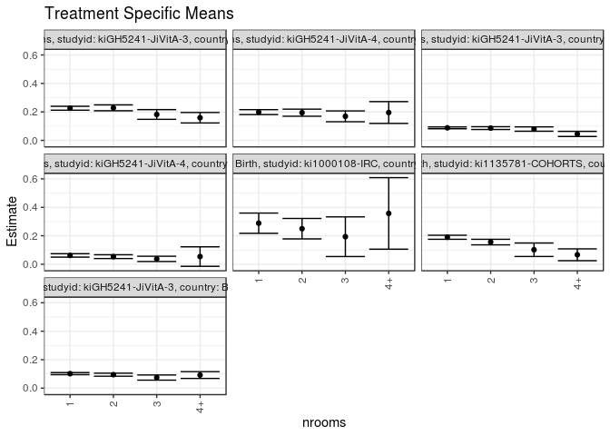

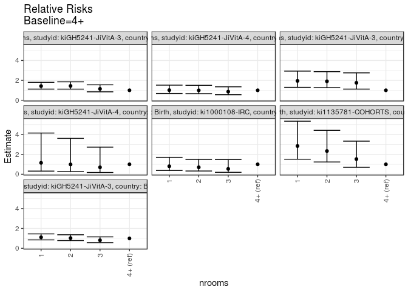

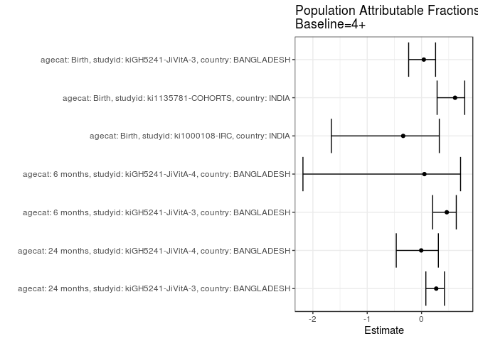

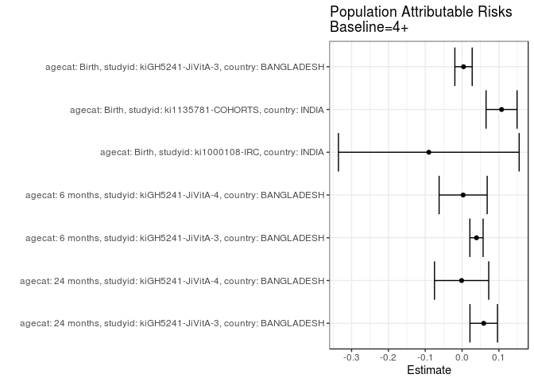

## Results Table

### Parameter: TSM

| agecat | studyid | country | intervention_level | baseline_level | estimate | ci_lower | ci_upper |
| --- | --- | --- | --- | --- | --- | --- | --- |
| Birth | ki1000108-IRC | INDIA | 4+ | NA | 0.3571429 | 0.1057806 | 0.6085051 |
| Birth | ki1000108-IRC | INDIA | 1 | NA | 0.2884615 | 0.2172637 | 0.3596594 |
| Birth | ki1000108-IRC | INDIA | 2 | NA | 0.2500000 | 0.1781673 | 0.3218327 |
| Birth | ki1000108-IRC | INDIA | 3 | NA | 0.1935484 | 0.0542683 | 0.3328284 |
| Birth | ki1135781-COHORTS | INDIA | 4+ | NA | 0.0666667 | 0.0250085 | 0.1083249 |
| Birth | ki1135781-COHORTS | INDIA | 1 | NA | 0.1896492 | 0.1753277 | 0.2039707 |
| Birth | ki1135781-COHORTS | INDIA | 2 | NA | 0.1558735 | 0.1363621 | 0.1753849 |
| Birth | ki1135781-COHORTS | INDIA | 3 | NA | 0.1019108 | 0.0545830 | 0.1492387 |
| Birth | kiGH5241-JiVitA-3 | BANGLADESH | 4+ | NA | 0.0919331 | 0.0680559 | 0.1158103 |
| Birth | kiGH5241-JiVitA-3 | BANGLADESH | 1 | NA | 0.1017819 | 0.0943899 | 0.1091739 |
| Birth | kiGH5241-JiVitA-3 | BANGLADESH | 2 | NA | 0.0945884 | 0.0839116 | 0.1052653 |
| Birth | kiGH5241-JiVitA-3 | BANGLADESH | 3 | NA | 0.0743055 | 0.0562653 | 0.0923458 |
| 6 months | kiGH5241-JiVitA-3 | BANGLADESH | 4+ | NA | 0.0452465 | 0.0271522 | 0.0633407 |
| 6 months | kiGH5241-JiVitA-3 | BANGLADESH | 1 | NA | 0.0880477 | 0.0817225 | 0.0943729 |
| 6 months | kiGH5241-JiVitA-3 | BANGLADESH | 2 | NA | 0.0861487 | 0.0763660 | 0.0959313 |
| 6 months | kiGH5241-JiVitA-3 | BANGLADESH | 3 | NA | 0.0794004 | 0.0641753 | 0.0946255 |
| 6 months | kiGH5241-JiVitA-4 | BANGLADESH | 4+ | NA | 0.0539735 | -0.0145375 | 0.1224845 |
| 6 months | kiGH5241-JiVitA-4 | BANGLADESH | 1 | NA | 0.0619939 | 0.0500733 | 0.0739145 |
| 6 months | kiGH5241-JiVitA-4 | BANGLADESH | 2 | NA | 0.0534769 | 0.0401932 | 0.0667606 |
| 6 months | kiGH5241-JiVitA-4 | BANGLADESH | 3 | NA | 0.0377720 | 0.0193778 | 0.0561661 |
| 24 months | kiGH5241-JiVitA-3 | BANGLADESH | 4+ | NA | 0.1590348 | 0.1222171 | 0.1958526 |
| 24 months | kiGH5241-JiVitA-3 | BANGLADESH | 1 | NA | 0.2258405 | 0.2121740 | 0.2395070 |
| 24 months | kiGH5241-JiVitA-3 | BANGLADESH | 2 | NA | 0.2286511 | 0.2080509 | 0.2492512 |
| 24 months | kiGH5241-JiVitA-3 | BANGLADESH | 3 | NA | 0.1819352 | 0.1477133 | 0.2161570 |
| 24 months | kiGH5241-JiVitA-4 | BANGLADESH | 4+ | NA | 0.1956803 | 0.1191258 | 0.2722347 |
| 24 months | kiGH5241-JiVitA-4 | BANGLADESH | 1 | NA | 0.1985195 | 0.1812102 | 0.2158289 |
| 24 months | kiGH5241-JiVitA-4 | BANGLADESH | 2 | NA | 0.1944394 | 0.1695166 | 0.2193622 |
| 24 months | kiGH5241-JiVitA-4 | BANGLADESH | 3 | NA | 0.1689862 | 0.1308504 | 0.2071220 |

### Parameter: E(Y)

| agecat | studyid | country | intervention_level | baseline_level | estimate | ci_lower | ci_upper |
| --- | --- | --- | --- | --- | --- | --- | --- |
| Birth | ki1000108-IRC | INDIA | NA | NA | 0.2668622 | 0.2198462 | 0.3138781 |
| Birth | ki1135781-COHORTS | INDIA | NA | NA | 0.1740009 | 0.1628660 | 0.1851358 |
| Birth | kiGH5241-JiVitA-3 | BANGLADESH | NA | NA | 0.0959454 | 0.0907405 | 0.1011503 |
| 6 months | kiGH5241-JiVitA-3 | BANGLADESH | NA | NA | 0.0844810 | 0.0796719 | 0.0892901 |
| 6 months | kiGH5241-JiVitA-4 | BANGLADESH | NA | NA | 0.0569712 | 0.0481278 | 0.0658146 |
| 24 months | kiGH5241-JiVitA-3 | BANGLADESH | NA | NA | 0.2179025 | 0.2080266 | 0.2277783 |
| 24 months | kiGH5241-JiVitA-4 | BANGLADESH | NA | NA | 0.1945032 | 0.1812962 | 0.2077102 |

### Parameter: RR

| agecat | studyid | country | intervention_level | baseline_level | estimate | ci_lower | ci_upper |
| --- | --- | --- | --- | --- | --- | --- | --- |
| Birth | ki1000108-IRC | INDIA | 4+ | 4+ | 1.0000000 | 1.0000000 | 1.000000 |
| Birth | ki1000108-IRC | INDIA | 1 | 4+ | 0.8076923 | 0.3831181 | 1.702783 |
| Birth | ki1000108-IRC | INDIA | 2 | 4+ | 0.7000000 | 0.3272990 | 1.497102 |
| Birth | ki1000108-IRC | INDIA | 3 | 4+ | 0.5419355 | 0.1980599 | 1.482855 |
| Birth | ki1135781-COHORTS | INDIA | 4+ | 4+ | 1.0000000 | 1.0000000 | 1.000000 |
| Birth | ki1135781-COHORTS | INDIA | 1 | 4+ | 2.8447378 | 1.5159635 | 5.338211 |
| Birth | ki1135781-COHORTS | INDIA | 2 | 4+ | 2.3381024 | 1.2362126 | 4.422154 |
| Birth | ki1135781-COHORTS | INDIA | 3 | 4+ | 1.5286624 | 0.7017657 | 3.329899 |
| Birth | kiGH5241-JiVitA-3 | BANGLADESH | 4+ | 4+ | 1.0000000 | 1.0000000 | 1.000000 |
| Birth | kiGH5241-JiVitA-3 | BANGLADESH | 1 | 4+ | 1.1071295 | 0.8458296 | 1.449152 |
| Birth | kiGH5241-JiVitA-3 | BANGLADESH | 2 | 4+ | 1.0288834 | 0.7777711 | 1.361070 |
| Birth | kiGH5241-JiVitA-3 | BANGLADESH | 3 | 4+ | 0.8082564 | 0.5685714 | 1.148982 |
| 6 months | kiGH5241-JiVitA-3 | BANGLADESH | 4+ | 4+ | 1.0000000 | 1.0000000 | 1.000000 |
| 6 months | kiGH5241-JiVitA-3 | BANGLADESH | 1 | 4+ | 1.9459565 | 1.2936318 | 2.927221 |
| 6 months | kiGH5241-JiVitA-3 | BANGLADESH | 2 | 4+ | 1.9039853 | 1.2614557 | 2.873791 |
| 6 months | kiGH5241-JiVitA-3 | BANGLADESH | 3 | 4+ | 1.7548412 | 1.1186781 | 2.752774 |
| 6 months | kiGH5241-JiVitA-4 | BANGLADESH | 4+ | 4+ | 1.0000000 | 1.0000000 | 1.000000 |
| 6 months | kiGH5241-JiVitA-4 | BANGLADESH | 1 | 4+ | 1.1485985 | 0.3181874 | 4.146232 |
| 6 months | kiGH5241-JiVitA-4 | BANGLADESH | 2 | 4+ | 0.9907985 | 0.2716516 | 3.613753 |
| 6 months | kiGH5241-JiVitA-4 | BANGLADESH | 3 | 4+ | 0.6998239 | 0.1794083 | 2.729827 |
| 24 months | kiGH5241-JiVitA-3 | BANGLADESH | 4+ | 4+ | 1.0000000 | 1.0000000 | 1.000000 |
| 24 months | kiGH5241-JiVitA-3 | BANGLADESH | 1 | 4+ | 1.4200696 | 1.1184427 | 1.803041 |
| 24 months | kiGH5241-JiVitA-3 | BANGLADESH | 2 | 4+ | 1.4377422 | 1.1169715 | 1.850631 |
| 24 months | kiGH5241-JiVitA-3 | BANGLADESH | 3 | 4+ | 1.1439958 | 0.8452774 | 1.548280 |
| 24 months | kiGH5241-JiVitA-4 | BANGLADESH | 4+ | 4+ | 1.0000000 | 1.0000000 | 1.000000 |
| 24 months | kiGH5241-JiVitA-4 | BANGLADESH | 1 | 4+ | 1.0145097 | 0.6784053 | 1.517131 |
| 24 months | kiGH5241-JiVitA-4 | BANGLADESH | 2 | 4+ | 0.9936587 | 0.6586118 | 1.499150 |
| 24 months | kiGH5241-JiVitA-4 | BANGLADESH | 3 | 4+ | 0.8635833 | 0.5529118 | 1.348816 |

### Parameter: PAR

| agecat | studyid | country | intervention_level | baseline_level | estimate | ci_lower | ci_upper |
| --- | --- | --- | --- | --- | --- | --- | --- |
| Birth | ki1000108-IRC | INDIA | 4+ | NA | -0.0902807 | -0.3356486 | 0.1550872 |
| Birth | ki1135781-COHORTS | INDIA | 4+ | NA | 0.1073342 | 0.0652317 | 0.1494368 |
| Birth | kiGH5241-JiVitA-3 | BANGLADESH | 4+ | NA | 0.0040123 | -0.0195121 | 0.0275368 |
| 6 months | kiGH5241-JiVitA-3 | BANGLADESH | 4+ | NA | 0.0392345 | 0.0212475 | 0.0572215 |
| 6 months | kiGH5241-JiVitA-4 | BANGLADESH | 4+ | NA | 0.0029977 | -0.0622624 | 0.0682578 |
| 24 months | kiGH5241-JiVitA-3 | BANGLADESH | 4+ | NA | 0.0588676 | 0.0214942 | 0.0962410 |
| 24 months | kiGH5241-JiVitA-4 | BANGLADESH | 4+ | NA | -0.0011771 | -0.0748245 | 0.0724703 |

### Parameter: PAF

| agecat | studyid | country | intervention_level | baseline_level | estimate | ci_lower | ci_upper |
| --- | --- | --- | --- | --- | --- | --- | --- |
| Birth | ki1000108-IRC | INDIA | 4+ | NA | -0.3383046 | -1.6601876 | 0.3267170 |
| Birth | ki1135781-COHORTS | INDIA | 4+ | NA | 0.6168602 | 0.2862315 | 0.7943365 |
| Birth | kiGH5241-JiVitA-3 | BANGLADESH | 4+ | NA | 0.0418188 | -0.2374823 | 0.2580814 |
| 6 months | kiGH5241-JiVitA-3 | BANGLADESH | 4+ | NA | 0.4644182 | 0.2049146 | 0.6392238 |
| 6 months | kiGH5241-JiVitA-4 | BANGLADESH | 4+ | NA | 0.0526174 | -2.1827736 | 0.7180026 |
| 24 months | kiGH5241-JiVitA-3 | BANGLADESH | 4+ | NA | 0.2701559 | 0.0791807 | 0.4215234 |
| 24 months | kiGH5241-JiVitA-4 | BANGLADESH | 4+ | NA | -0.0060518 | -0.4657175 | 0.3094575 |